# Salary Exploratory Data Analysis

Natalia Trąba

2023-11-23

### Wprowadzenie

Pakiety, których będę używała:

```r
library(mice)
library(psych)
library(tidyr)
library(ggplot2)
library(dplyr)
library(utils)
library(knitr)
library(kableExtra)
```

Wczytuje plik wybrany przeze mnie do analizy.

```r
salary <- read.csv("C:/Users/Natalia/Desktop/Salary.csv", sep = ";") %>% select(-4)
```

Na samym początku korzystam z dwóch funkcji `head()` i `tail()`, które pozwolą mi zobaczyć kilka pierwszych i ostatnich wierszy moich danych.

```r
head(salary,5)
```

```
##   Age Gender Education.Level        Job.Title Years.of.Experience Salary
## 1  23 Female Bachelor Degree Project Engineer                   0  51831
## 2  23 Female Bachelor Degree Project Engineer                   0  52831
## 3  23 Female Bachelor Degree Project Engineer                   0  52831
## 4  23 Female Bachelor Degree Project Engineer                   0  52831
## 5  24 Female     High School Project Engineer                   1  52731
##     Country  Race Senior
## 1 Australia Asian      1
## 2    Canada White      1
## 3     China White      1
## 4       USA Asian      1
## 5    Canada Black      1
```

```r
tail(salary,5)
```

```
##      Age Gender Education.Level                 Job.Title Years.of.Experience
## 6680  62   Male             Phd Software Engineer Manager                  20
## 6681  62   Male             Phd Software Engineer Manager                  20
## 6682  62   Male             Phd Software Engineer Manager                  19
## 6683  62   Male             Phd Software Engineer Manager                  19
## 6684  62   Male             Phd Software Engineer Manager                  19
##      Salary   Country   Race Senior
## 6680 200000     China Korean      0
## 6681 200000    Canada  Asian      0
## 6682 200000        UK  White      0
## 6683 200000        UK  Mixed      0
## 6684 200000 Australia  Asian      0
```

Następnie sprawdzam strukturę mojego pliku.

```r
str(salary)
```

```
## 'data.frame':    6684 obs. of  9 variables:
##  $ Age                : num  23 23 23 23 24 24 26 26 26 26 ...
##  $ Gender             : chr  "Female" "Female" "Female" "Female" ...
##  $ Education.Level    : chr  "Bachelor Degree" "Bachelor Degree" "Bachelor Degree" "Bachelor Degree" ...
##  $ Job.Title          : chr  "Project Engineer" "Project Engineer" "Project Engineer" "Project Engineer" ...
##  $ Years.of.Experience: int  0 0 0 0 1 1 2 2 5 5 ...
##  $ Salary             : int  51831 52831 52831 52831 52731 52731 55000 55000 85000 85000 ...
##  $ Country            : chr  "Australia" "Canada" "China" "USA" ...
##  $ Race               : chr  "Asian" "White" "White" "Asian" ...
##  $ Senior             : int  1 1 1 1 1 1 1 1 1 1 ...
```

### Wartości brakujące

Po pierwszym wglądzie do danych mogę przypuszcać, że braków danych raczej nie ma. Potwierdzę to jednak poprzez wykorzystanie funkcji `(md.pattern)` z pakietu mice.

```
##  /\     /\
## {  `---'  }
## {  O   O  }
## ==>  V <==  No need for mice. This data set is completely observed.
##  \  \|/  /
##   `-----'
```

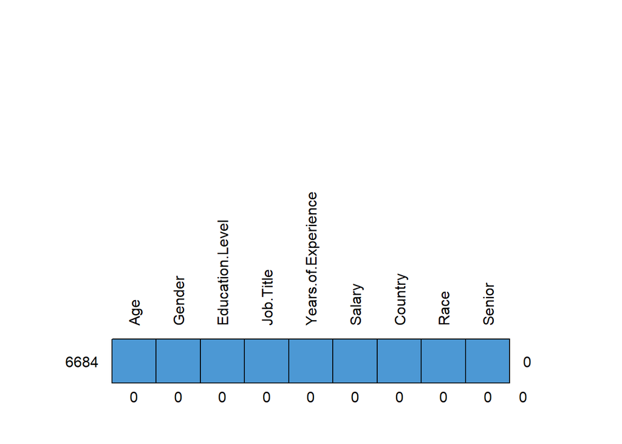

```
##      Age Gender Education.Level Job.Title Years.of.Experience Salary Country
## 6684   1      1               1         1                   1      1       1
##        0      0               0         0                   0      0       0
##      Race Senior
## 6684    1      1 0
##         0      0 0
```

```r
md.pattern(salary, plot = TRUE, rotate.names = TRUE)
```

A więc, mam do czynienia z danymi czystymi, jednak łatwo zauważyć, że w tym zestawie jest dużo zmiennych tekstowych, moją pracę zacznę więc od bliższego ich poznania.

### Zmienne tekstowe

- zmienna `(Gender)` - płeć osoby badanej. Zamieniam ją na zmienną kategoryczną, ponieważ jako faktor będzie lepiej pasować do kolejnych przekształceń.

```r
salary$Gender <- as.factor(salary$Gender)
table(salary$Gender)
```

```
##
## Female   Male
##   3013   3671
```

- zmienna `(Educational Level)` - informuje nas jaki stopień naukowy posiada osoba. Sprawdzam zatem jakie stopnie naukowe występują w danych i zamieniam tą zmienną na typ factor. Dodatkowo nadaję kolejność poszczególnym kategoriom - od najniższego do najwyższego stopnia.

```r
salary$Education.Level <- as.factor(salary$Education.Level)
levels(salary$Education.Level) <- c("High School", "Bachelor Degree", "Master Degree", "Phd")
table(salary$Education.Level)
```

```
##
##     High School Bachelor Degree   Master Degree             Phd
##            3021             436            1858            1369
```

Każda klasa jest liczna, przedstawię to też na wykresie w celu lepszej wizualizacji.

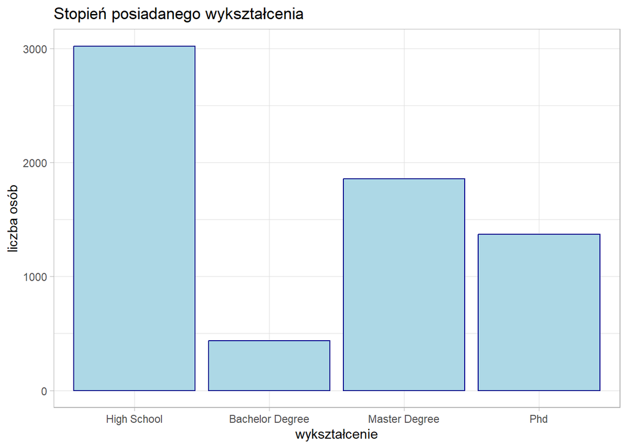

```r
salary %>%
  ggplot() +
  geom_bar(aes(x = Education.Level),
           color = "darkblue", fill = "lightblue") +
  theme_light() +
  labs(title = "Stopień posiadanego wykształcenia",
       x = "wykształcenie",
       y = "liczba osób")
```

Jak można zauważyć, wśród badanych najmniej osób ma tytuł licencjata/inżyniera. Później przejdę do analizy co i czemu na to wpływa.

- zmienna `(Job Title)` - zawód osoby badanej, ją także zamieniam na zmienną kategoryczną. Nie ma ona określonej kolejności, ale gdy będzie typem factor łatwiej będzie prowadzić dalszą analizę.

```r
salary$Job.Title <- as.factor(salary$Job.Title)
head(salary$Job.Title, 8)
```

```
## [1] Project Engineer Project Engineer Project Engineer Project Engineer
## [5] Project Engineer Project Engineer HR Generalist    HR Generalist
## 129 Levels: Account Executive Account Manager ... Web Developer
```

- Ze zmiennymi `(Country)` i `(Race)` postępuje analogicznie jak wyżej.

```r
salary$Country <- as.factor(salary$Country)
levels(salary$Country) <- c("Australia","Canada", "China", "UK", "USA")
salary$Race <- as.factor(salary$Race)
table(salary$Country)
```

```
##
## Australia    Canada     China        UK       USA
##      1335      1322      1339      1332      1356
```

```r
table(salary$Race)
```

```
##
## African American            Asian       Australian            Black
##              352             1599              452              435
##          Chinese         Hispanic           Korean            Mixed
##              443              322              457              334
##            Welsh            White
##              333             1957
```

```r
salary <- salary %>%
  mutate(
    Race = ifelse(Race %in% c("Chinese", "Asian", "Korean"), "Asian people",
                 ifelse(Race %in% c("Hispanic", "White", "Welsh", "Australian"), "White people",
                        ifelse(Race %in% c("Black", "African American"), "Black people",
                               ifelse(Race %in% c("Mixed"), "Mixed", Race)))

  ))
salary$Race <- as.factor(salary$Race)
table(salary$Race)
```

```
##
## Asian people Black people        Mixed White people
##         2499          787          334         3064
```

```r
salary$Senior <- as.factor(salary$Senior)
levels(salary$Senior) <- c("Nie", "Tak")
table(salary$Senior)
```

```
##
##  Nie  Tak
## 5725  959
```

### Zmienne ilościowe

Teraz przejdę do przeanalizowania zmiennych ilościowych

- zmienna `(Age)` - jej rozkład jest następujący:

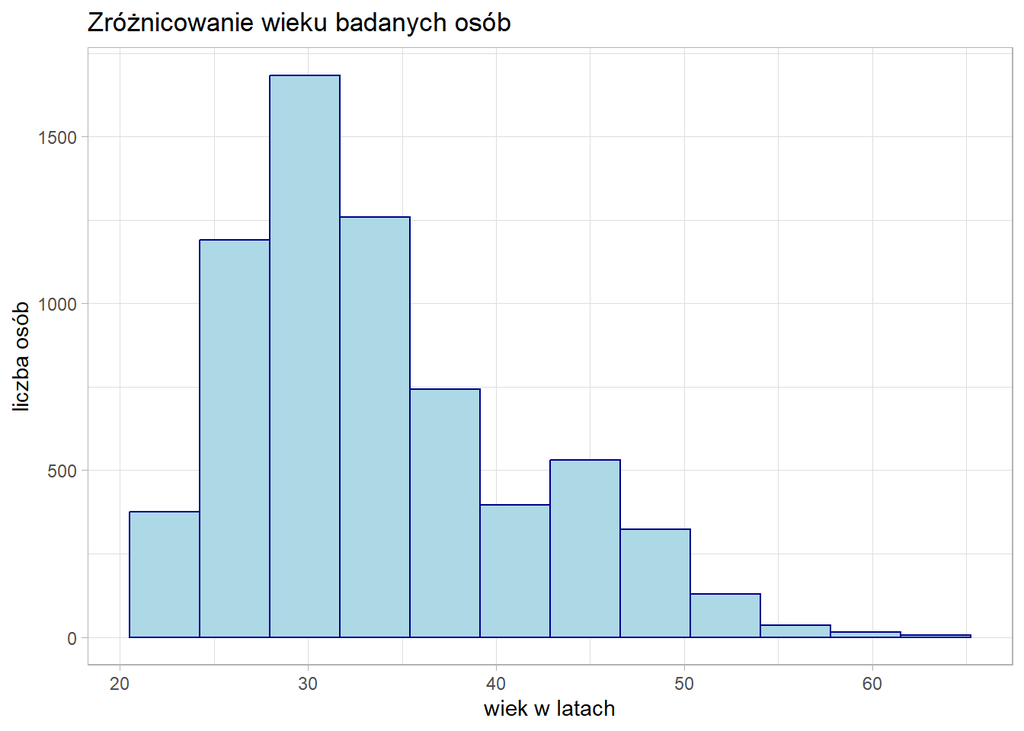

```r
salary %>%
  ggplot() +
  geom_histogram(aes(x = Age), bins = 12,
                 color = "darkblue", fill = "lightblue") +
  theme_light() +
  labs(title = "Zróżnicowanie wieku badanych osób",
       x = "wiek w latach",
       y = "liczba osób")
```

A więc dane dotyczą głównie osób młodych, a rozkład jest prawostronnie skośny. Statystki opisowe dla zmiennej `(Age)`.

```r
summary(salary$Age)
```

```
##    Min. 1st Qu.  Median    Mean 3rd Qu.    Max.
##   21.00   28.00   32.00   33.61   38.00   62.00
```

- zmienna `(Years of Experience)` - lata doświadczenia w branży osoby badanej. Tym razem jej rozkład przedstawię na krzywej gęstości, spodziewam się również rozkładu prawostronnie skośnego.

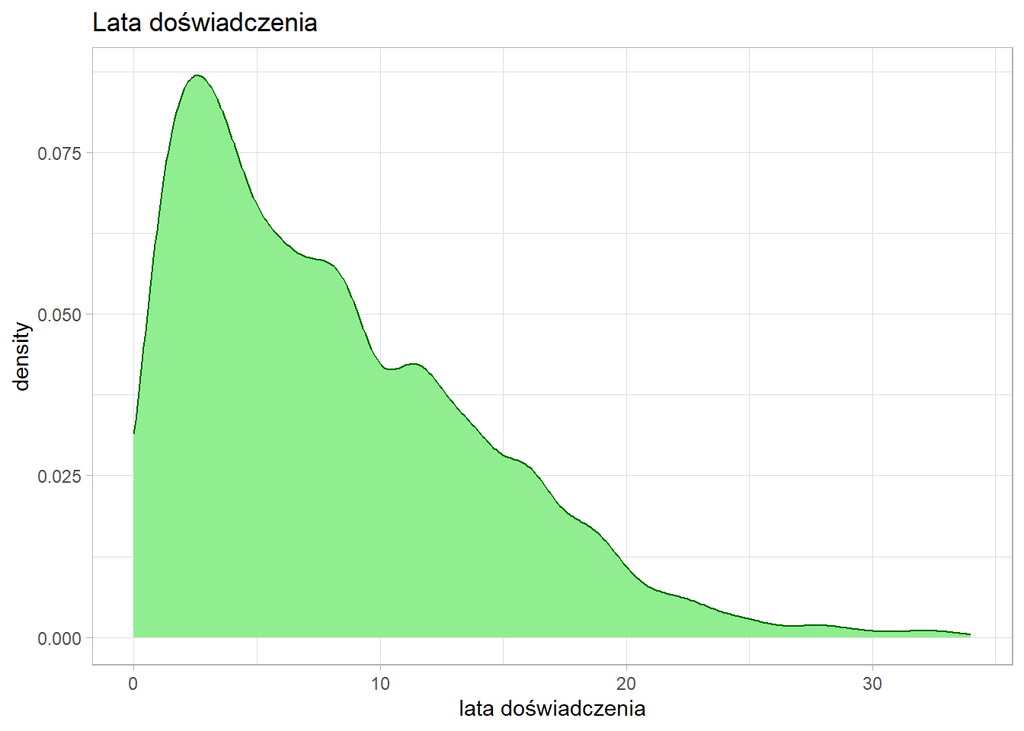

```r
salary %>%
  ggplot() +
  geom_density(aes(x = Years.of.Experience),
                 color = "darkgreen", fill = "lightgreen") +
  theme_light() +
  labs(title = "Lata doświadczenia",
       x = "lata doświadczenia")
```

Wyznaczę jeszcze podstawowe statystyki opisowe.

```r
summary(salary$Years.of.Experience)
```

```
##    Min. 1st Qu.  Median    Mean 3rd Qu.    Max.
##   0.000   3.000   7.000   8.081  12.000  34.000
```

Można zauważyć, że w zestawie dominują osoby z niższym stażem pracy, a mniej jest osób doświadczonych, wykres jest prawostronnie skośny, Zapewne wynika to wprost z rozkładu wieku osób. Sprawdzę teraz czy istnieją tutaj wartości odstające.

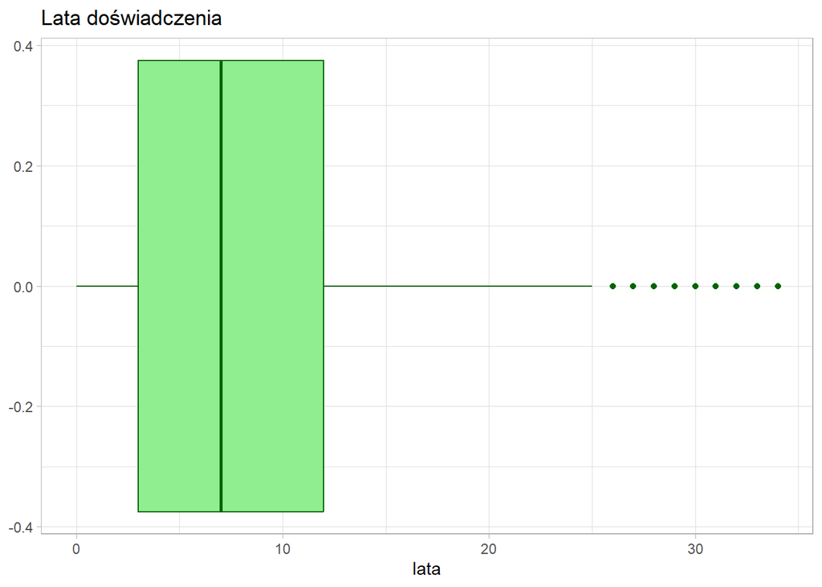

```r
salary %>%
  ggplot() +
  geom_boxplot(aes(x = Years.of.Experience),
                 color = "darkgreen", fill = "lightgreen") +
  theme_light() +
  labs(title = "Lata doświadczenia",
       x = "lata")
```

Wykres pudełkowy pokazuje wartości odstające. Nie ma sensu ich narazie usuwać, gdyż w dalszej części mojej analizy dokładniej im się przyjrzę.

- zmienna `(salary)` - roczne zarobki osoby badanej wyrażone w USD. Zobaczę rozkład tej zmiennej.

```r
quantile(salary$Salary,
         probs = c(0, 0.25, 0.5, 0.75, 0.95, 0.99, 1))
```

```
##     0%    25%    50%    75%    95%    99%   100%
##  25000  70000 115000 160000 195000 210000 250000
```

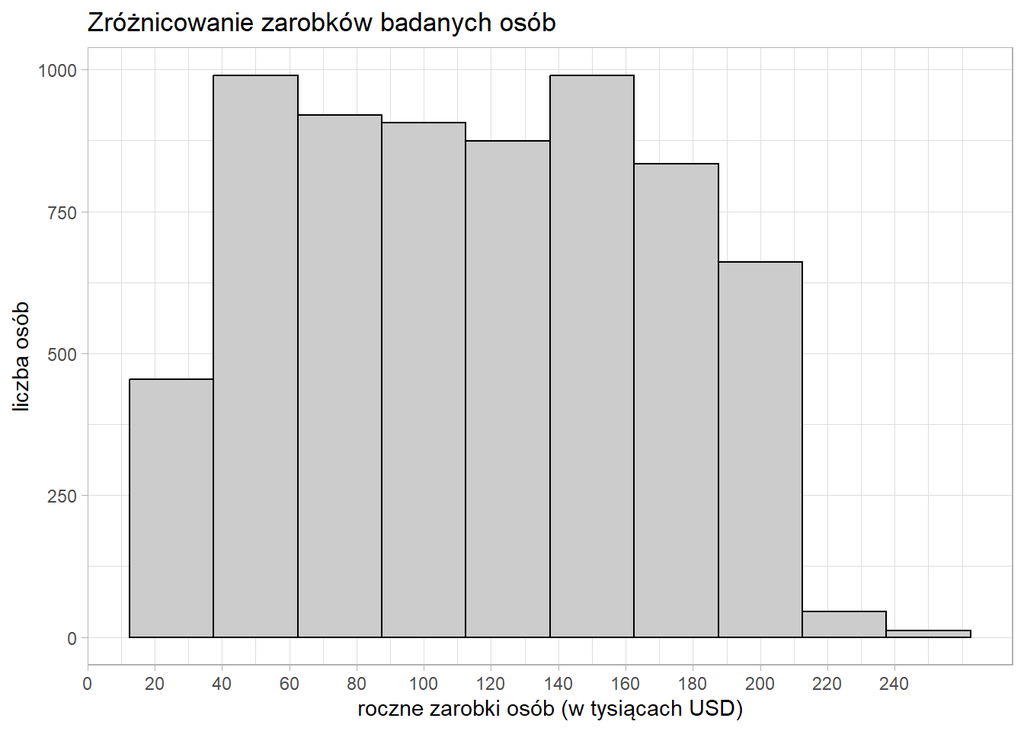

```r
salary %>%
  ggplot() +
  geom_histogram(aes(x = Salary),
                 bins = 10,
                 color = "black", fill = "grey80") +
  theme_light() +
  scale_x_continuous(labels = scales::comma_format(scale = 1e-3),
                     breaks = seq(0, max(salary$Salary), by = 20000)) +
  labs(title = "Zróżnicowanie zarobków badanych osób",
       x = "roczne zarobki osób (w tysiącach USD)",
       y = "liczba osób")
```

```r
salary <- salary %>%
  mutate(Monthly.salary = Salary / 12)

head(salary$Monthly.salary)
```

```
## [1] 4319.250 4402.583 4402.583 4402.583 4394.250 4394.250
```

Tą część zadania kończę wyznaczeniem statystyk opisowych osobno dla zmiennych kategorycznych i ilościowych.

```r
summary(salary)
```

```
##       Age           Gender            Education.Level
##  Min.   :21.00   Female:3013   High School    :3021
##  1st Qu.:28.00   Male  :3671   Bachelor Degree: 436
##  Median :32.00                 Master Degree  :1858
##  Mean   :33.61                 Phd            :1369
##  3rd Qu.:38.00
##  Max.   :62.00
##
##                      Job.Title    Years.of.Experience     Salary
##  Software Engineer        : 809   Min.   : 0.000      Min.   : 25000
##  Data Scientist           : 515   1st Qu.: 3.000      1st Qu.: 70000
##  Data Analyst             : 391   Median : 7.000      Median :115000
##  Software Engineer Manager: 376   Mean   : 8.081      Mean   :115336
##  Product Manager          : 323   3rd Qu.:12.000      3rd Qu.:160000
##  Project Engineer         : 317   Max.   :34.000      Max.   :250000
##  (Other)                  :3953
##       Country               Race      Senior     Monthly.salary
##  Australia:1335   Asian people:2499   Nie:5725   Min.   : 2083
##  Canada   :1322   Black people: 787   Tak: 959   1st Qu.: 5833
##  China    :1339   Mixed       : 334              Median : 9583
##  UK       :1332   White people:3064              Mean   : 9611
##  USA      :1356                                  3rd Qu.:13333
##                                                  Max.   :20833
##
```

```r
salary %>%
  select(Age, Years.of.Experience, Salary, Monthly.salary) %>%
  describe()
```

```
##                     vars    n      mean       sd    median   trimmed      mad
## Age                    1 6684     33.61     7.60     32.00     32.81     7.41
## Years.of.Experience    2 6684      8.08     6.03      7.00      7.44     5.93
## Salary                 3 6684 115336.49 52757.08 115000.00 115147.23 66717.00
## Monthly.salary         4 6684   9611.37  4396.42   9583.33   9595.60  5559.75
##                          min       max  range skew kurtosis     se
## Age                    21.00     62.00     41 0.90     0.18   0.09
## Years.of.Experience     0.00     34.00     34 0.97     0.71   0.07
## Salary              25000.00 250000.00 225000 0.06    -1.17 645.30
## Monthly.salary       2083.33  20833.33  18750 0.06    -1.17  53.78
```

### Zależności między zmiennymi

Jak już wcześniej stwierdziłam, występuje silna zależność pomiędzy wiekiem, a liczbą lat doświadczenia zawodowego.Gdyż obydwie zmienne mają rozkład prawostronnie skośny wyznaczę współczynnik korelacji Spearmana.

```r
cor = cor(salary[,c("Age", "Years.of.Experience")],
          method = "spearman")
round(cor, 2)
```

```
##                      Age Years.of.Experience
## Age                 1.00                0.95
## Years.of.Experience 0.95                1.00
```

Zmienne są skorelowane ze sobą w stopinu bardzo wysokim, prawie liniowym. Dodatkowo przedstawię tą zależność na wykresie pudełkowym z podziałem na trzy grupy wiekowe, aby sprawdzić jak w zależności od grupy wiekowej kształtuje się ta zależność.

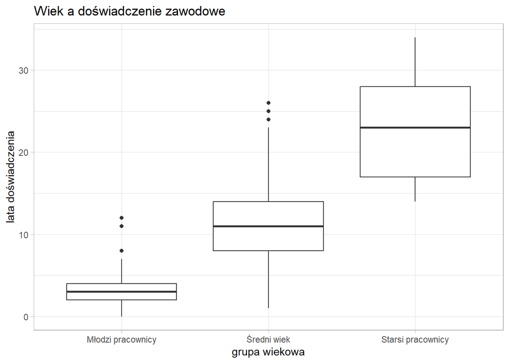

```r
salary$group <- cut(salary$Age, breaks = c(0, 30, 50, Inf), labels = c("Młodzi pracownicy", "Średni wiek", "Starsi pracownicy"))
salary %>%
  ggplot() +
  geom_boxplot(aes(x = group , y = Years.of.Experience)) +
  theme_light() +
  labs(title = "Wiek a doświadczenie zawodowe",
       x = "grupa wiekowa",
       y = "lata doświadczenia")
```

Występuje kilka wartości odstających, jednak to grupa starszych pracowników jest najbardziej “zróżnicowana” pod względem stażu pracy. Dokładniej tą zależność przedstawia poniższy wykres punktowy.

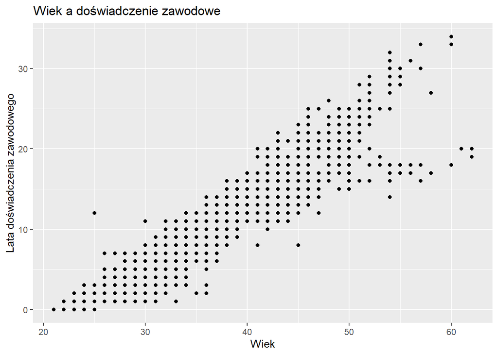

```r
ggplot(salary, aes(x = Age, y = Years.of.Experience)) +
  geom_point() +
  labs(title = "Wiek a doświadczenie zawodowe",
       x = "Wiek",
       y = "Lata doświadczenia zawodowego")
```

Podsumowując, zmienne `(Age)` i `(Years of Experience)` są mocno skorelowane ze sobą, przeważnie im starszy pracownik, tym ma więcej lat doświadczenia w zawodzie.

Teraz zastanowię się czy poziom posiadanego wykształcenia zależy od płci. Na początek wyznaczę ilość osób przynależących do danej grupy.

```r
table(salary[,c("Gender", "Education.Level")])
```

```
##         Education.Level
## Gender   High School Bachelor Degree Master Degree  Phd
##   Female        1198             251          1068  496
##   Male          1823             185           790  873
```

Przedstawię też tą zależność na wykresie.

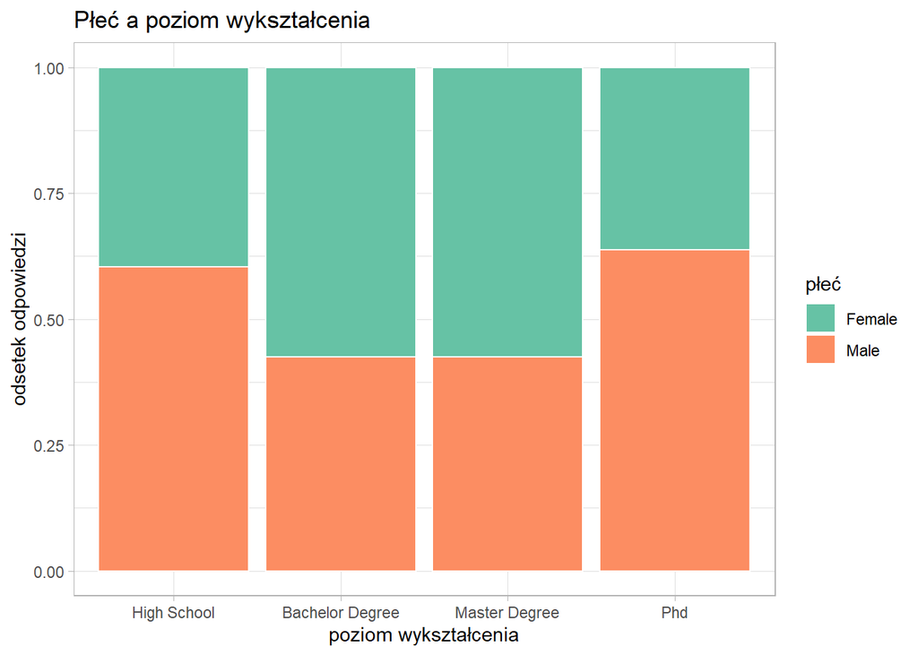

```r
salary %>%
  ggplot() +
  geom_bar(aes(x = Education.Level, fill = Gender),
           color = "white",
           position = "fill") +
  scale_fill_brewer(palette="Set2") +
  theme_light() +
  labs(title = "Płeć a poziom wykształcenia",
       x = "poziom wykształcenia",
       y = "odsetek odpowiedzi",
       fill = "płeć")
```

Kobiety częściej kontynuują naukę na uczelniach wyższych, jednak to mężczyźni stosunkowo częściej sięgają po tytuł doktora. Czy i w jaki sposób wpływa to na późniejsze zarobki w pracy?

Obliczę średnią zarobków dla każdego poziomu wykształcenia - osobno dla kobiet i mężczyzn.

```r
srednie_zarobki <- salary %>%
  group_by(Education.Level, Gender) %>%
  summarise(srednia_zarobki = mean(Monthly.salary))
print(srednie_zarobki)
```

```
## # A tibble: 8 × 3
## # Groups:   Education.Level [4]
##   Education.Level Gender srednia_zarobki
##   <fct>           <fct>            <dbl>
## 1 High School     Female           7438.
## 2 High School     Male             8249.
## 3 Bachelor Degree Female           2563.
## 4 Bachelor Degree Male             3282.
## 5 Master Degree   Female          10225.
## 6 Master Degree   Male            11672.
## 7 Phd             Female          13356.
## 8 Phd             Male            14065.
```

Narysuje jeszcze wykres przedstawiający tą zależność.

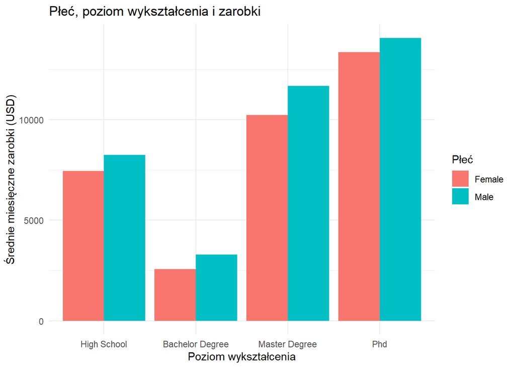

```r
ggplot(salary, aes(x = Education.Level, y = Monthly.salary, fill = Gender)) +
  stat_summary(fun = "mean", geom = "bar", position = "dodge") +
  labs(title = "Płeć, poziom wykształcenia i zarobki",
       x = "Poziom wykształcenia",
       y = "Średnie miesięczne zarobki (USD)",
       fill = "Płeć") +
  theme_minimal()
```

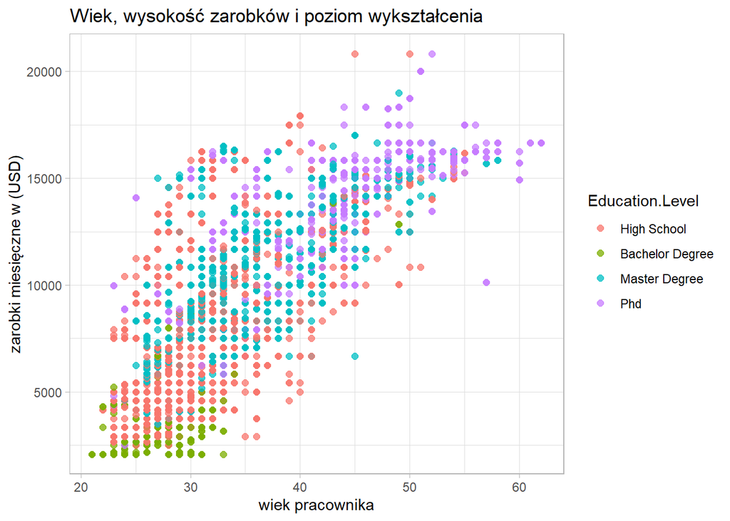

```r
salary %>%
  ggplot() +
  geom_point(aes(x = Age, y = Monthly.salary , col = Education.Level),
             size = 2, alpha = 0.75) +
  theme_light() +
  labs(title = "Wiek, wysokość zarobków i poziom wykształcenia",
       x = "wiek pracownika",
       y = "zarobki miesięczne w (USD)",
       fill = "poziom wykształcenia")
```

Powyższy wykres przedstawia wysokość zarobków poszczególnych osób w zależności od wysokości zarobków i poziomu wykształcenia. Wyraźnie widać, że osoby zarabiające najwięcej są starsze i mają wysoki poziom wykształcenia. Pojawiła się także ciekawa zależność pomiędzy poziomem wykształcenia a wiekiem osoby.

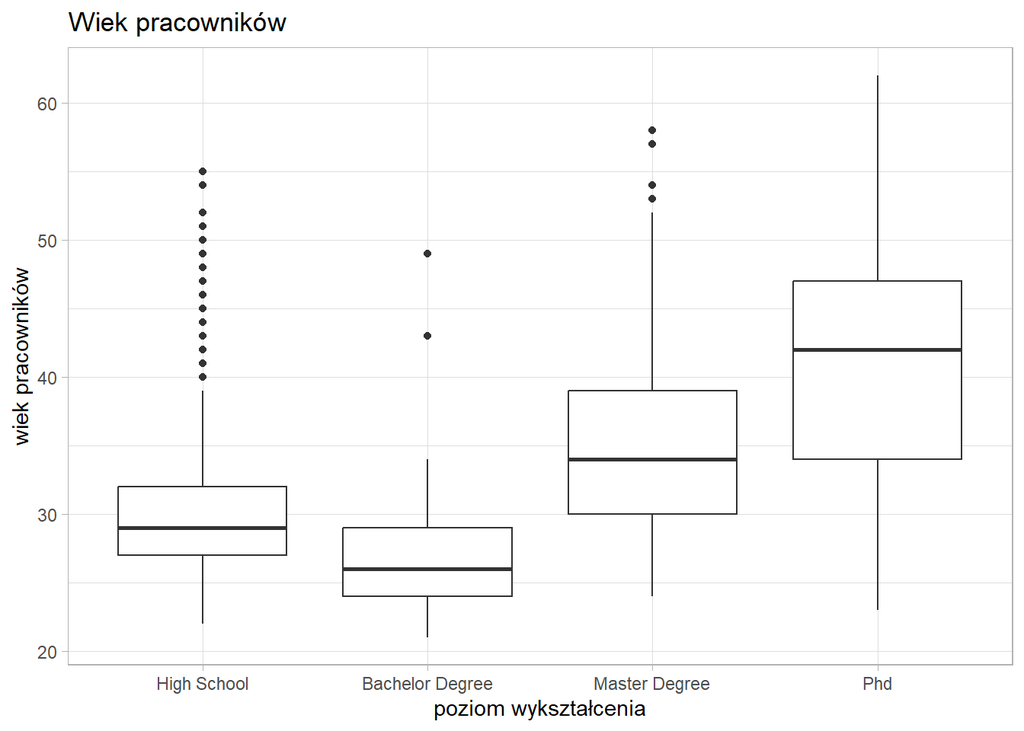

```r
salary %>%
  ggplot() +
  geom_boxplot(aes(x = Education.Level, y = Age)) +
  theme_light() +
  labs(title = "Wiek pracowników",
       x = "poziom wykształcenia",
       y = "wiek pracowników")
```

Z reguły osoby z najwyższym wykształceniem są najstarsze, co można przełożyć również na rzeczywistość. Ciekawą sprawą może być to, że w badaniu uczestniczyło też sporo osób starszych z wykształceniem średnim lub licencjatem/inżynierem - mówią o tym wartości odstające. Może to wynikać z faktu, że dawniej uczelnie wyższe nie były tak dostępne dla każdego jak w dzisiejszych czasach i jedynie część osób decydowała się na dalszą kontynuację nauki.

Czy zarobki zależą od rasy?

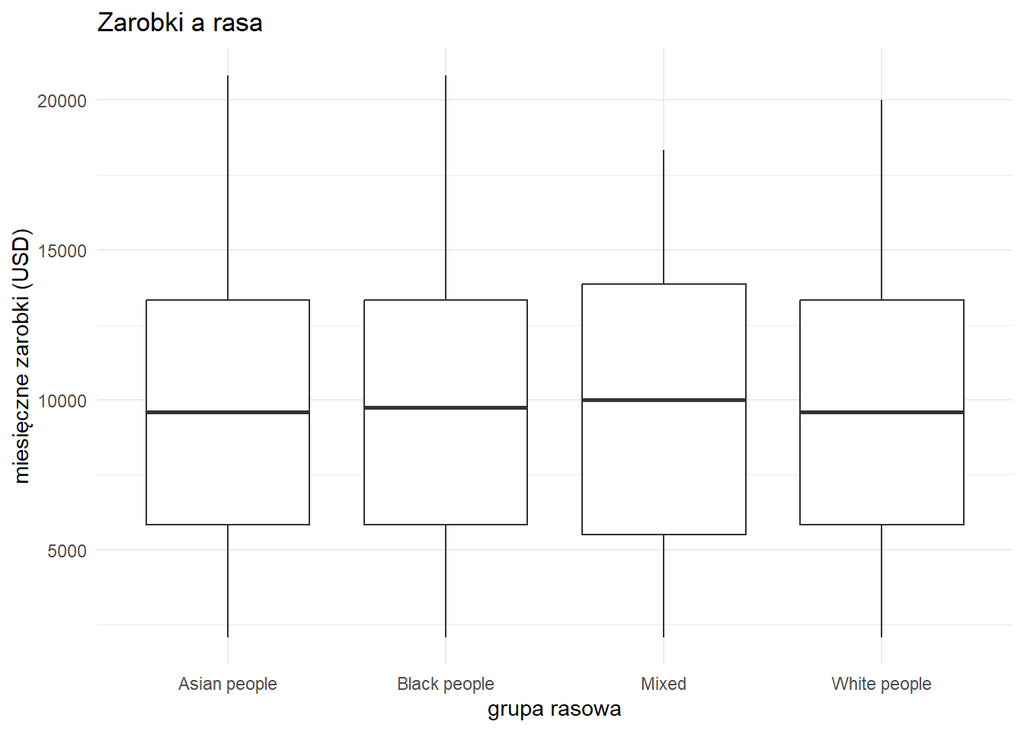

```r
ggplot(salary, aes(x = Race, y = Monthly.salary)) +
  geom_boxplot() +
  labs(title = "Zarobki a rasa",
       x = "grupa rasowa",
       y = "miesięczne zarobki (USD)") +
  theme_minimal()
```

Czy wysokość zarobków zależy od kraju zatrudnienia?

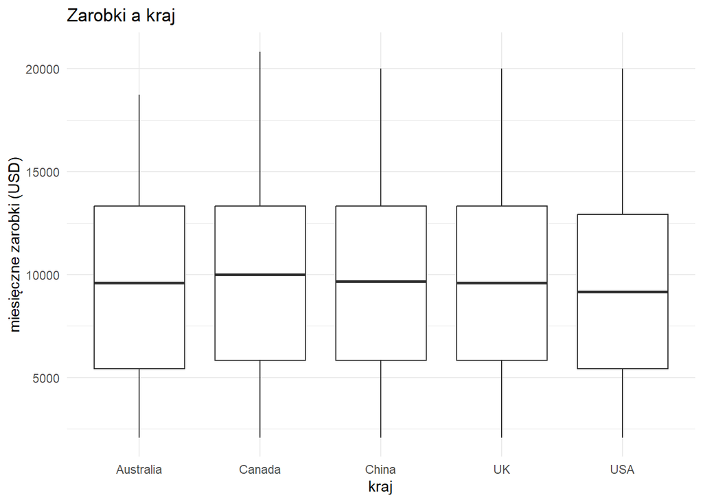

```r
ggplot(salary, aes(x = Country, y = Monthly.salary)) +
  geom_boxplot() +
  labs(title = "Zarobki a kraj",
       x = "kraj",
       y = "miesięczne zarobki (USD)") +
  theme_minimal()
```

```r
miesieczne_zarobki <- salary %>%
  group_by(Country, Race) %>%
  summarise(Miesieczna_Pensja_sr = mean(Monthly.salary))
print(miesieczne_zarobki)
```

```
## # A tibble: 13 × 3
## # Groups:   Country [5]
##    Country   Race         Miesieczna_Pensja_sr
##    <fct>     <fct>                       <dbl>
##  1 Australia Asian people                9534.
##  2 Australia White people                9601.
##  3 Canada    Asian people                9597.
##  4 Canada    Black people                9868.
##  5 Canada    White people                9654.
##  6 China     Asian people                9518.
##  7 China     White people               10043.
##  8 UK        Asian people                9877.
##  9 UK        Mixed                       9722.
## 10 UK        White people                9534.
## 11 USA       Asian people                9454.
## 12 USA       Black people                9363.
## 13 USA       White people                9437.
```

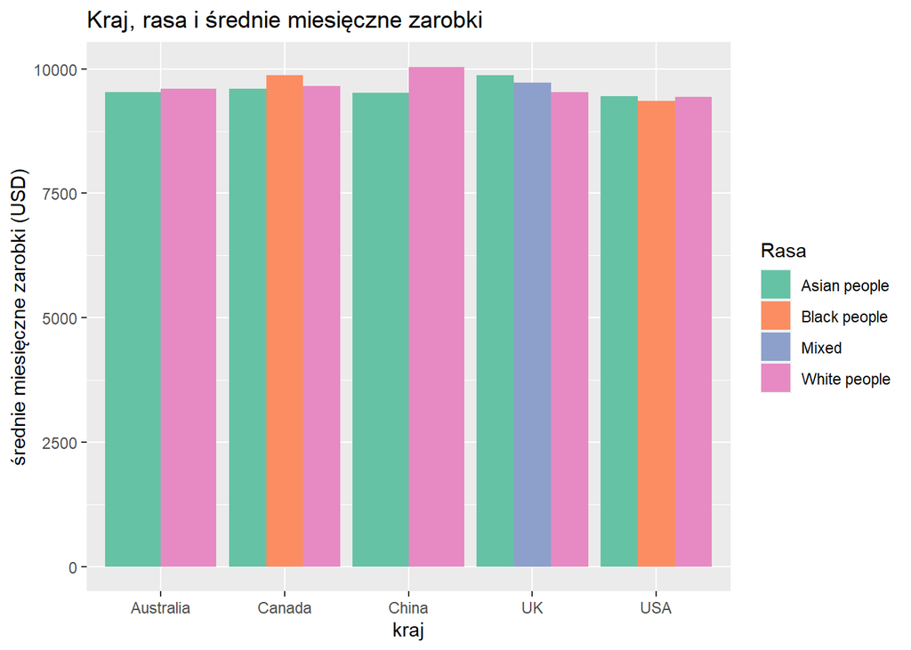

```r
rasa_palette <- c("#66c2a5", "#fc8d62", "#8da0cb", "#e78ac3", "#a6d854")

ggplot(miesieczne_zarobki, aes(x = Country, y = Miesieczna_Pensja_sr, fill = Race)) +
  geom_bar(stat = "identity", position = "dodge") +
  labs(title = "Kraj, rasa i średnie miesięczne zarobki", x = "kraj", y = "średnie miesięczne zarobki (USD)", fill = "Rasa") +
  scale_fill_manual(values = rasa_palette)
```

Widać niewielkie różnice w średnich miesięcznych zarobkach pomiędzy krajami i rasami.

Zobaczę teraz które stanowiska są przeciętnie najlepiej i najgorzej płatne. Porządkuję średnią miesięczną wysokość zarobków na danym stanowisku od największej do najmniejszej.

```r
srednie_zarobki_stanowiska <- salary %>%
  group_by(Job.Title) %>%
  summarise(srednia_zarobki = mean(Monthly.salary)) %>%
  arrange(desc(srednia_zarobki))
head(srednie_zarobki_stanowiska, 8)
```

```
## # A tibble: 8 × 2
##   Job.Title                srednia_zarobki
##   <fct>                              <dbl>
## 1 CEO                               20833.
## 2 Chief Technology Officer          20833.
## 3 Chief Data Officer                18333.
## 4 Director of Data Science          17047.
## 5 Director                          16667.
## 6 VP of Finance                     16667.
## 7 Operations Director               15833.
## 8 VP of Operations                  15833.
```

```r
tail(srednie_zarobki_stanowiska, 8)
```

```
## # A tibble: 8 × 2
##   Job.Title                       srednia_zarobki
##   <fct>                                     <dbl>
## 1 Customer Support Specialist               2917.
## 2 Data Entry Clerk                          2917.
## 3 Help Desk Analyst                         2917.
## 4 Customer Service Representative           2778.
## 5 Juniour HR Coordinator                    2667.
## 6 Sales Associate                           2561.
## 7 Delivery Driver                           2333.
## 8 Receptionist                              2083.
```

A czy wysokość średnich miesięcznych zarobków dla tego samego stanowiska różni się istotnie w zależności od kraju?

```r
srednie_zarobki_stanowiska_kraje <- salary %>%
  group_by(Job.Title, Country) %>%
  summarise(srednia_zarobki = mean(Monthly.salary))

liczba_unikalnych_krajow <- n_distinct(salary$Country)

stanowiska_we_wszystkich_krajach <- srednie_zarobki_stanowiska_kraje %>%
  group_by(Job.Title) %>%
  filter(n_distinct(Country) == liczba_unikalnych_krajow)

srednie_zarobki_wide <- stanowiska_we_wszystkich_krajach %>%
  spread(key = Country, value = srednia_zarobki)

head(srednie_zarobki_wide,8)
```

```
## # A tibble: 8 × 6
## # Groups:   Job.Title [8]
##   Job.Title                    Australia Canada  China     UK    USA
##   <fct>                            <dbl>  <dbl>  <dbl>  <dbl>  <dbl>
## 1 Back end Developer               8860.  8167.  8783.  8351.  8566.
## 2 Business Analyst                 5917.  6389.  8125   9500   4722.
## 3 Content Marketing Manager        9199. 10658. 11859. 10049.  9280.
## 4 Data Analyst                     9817.  9986.  9874. 10425. 10193.
## 5 Data Scientist                  14132. 13945. 13292. 13658. 13202.
## 6 Digital Marketing Manager        7468.  7014.  7674.  8000   8447.
## 7 Digital Marketing Specialist     5417.  5167.  5417.  5000   5000
## 8 Director of Data Science        16806. 17308. 16970. 17130. 17014.
```

```r
tail(srednie_zarobki_wide,8)
```

```
## # A tibble: 8 × 6
## # Groups:   Job.Title [8]
##   Job.Title                 Australia Canada  China     UK    USA
##   <fct>                         <dbl>  <dbl>  <dbl>  <dbl>  <dbl>
## 1 Sales Executive               3194.  3000   4219.  3333.  5000
## 2 Sales Manager                 8167. 10784.  7005.  8155.  8542.
## 3 Sales Representative          3229.  3646.  3773.  3482.  3393.
## 4 Social Media Manager          4167.  4583.  4583.  4583.  4583.
## 5 Software Developer            4505   4625   4718.  5073.  4746.
## 6 Software Engineer             9842. 10355. 10104.  9945.  9975.
## 7 Software Engineer Manager    14486. 14324. 14782. 14134. 14173.
## 8 Web Developer                 4917.  4983.  4688.  5288.  4993.
```

Czy osoby na stanowiskach seniorskich zazwyczaj zarabiają więcej niż inne?

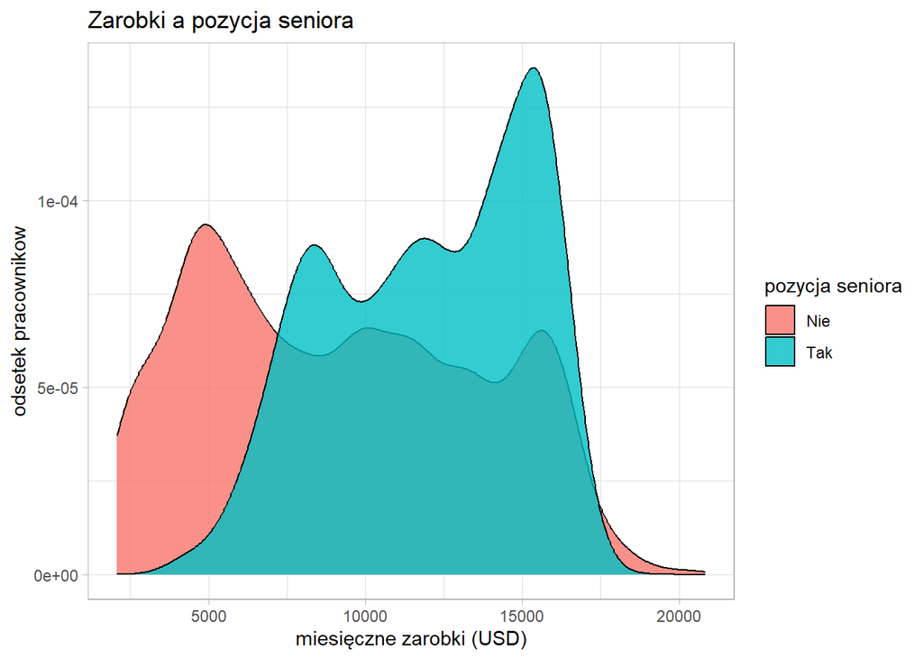

```r
salary %>%
  ggplot() +
  geom_density(aes(x = Monthly.salary, fill = Senior),
               alpha = 0.8) +
  theme_light() +
  labs(title = "Zarobki a pozycja seniora",
       x = "miesięczne zarobki (USD)",
       y = "odsetek pracownikow",
       fill = "pozycja seniora")
```

```r
statystyki_opisowe_k_s <- salary %>%
  group_by(Country, Senior) %>%
  summarise(
    Liczba_Osob = n(),
    Srednia_Zarobkow = mean(Monthly.salary),
    Mediana_Zarobkow = median(Monthly.salary),
    Odchylenie_Standardowe = sd(Monthly.salary),
    Minimum_Zarobkow = min(Monthly.salary),
    Maksimum_Zarobków = max(Monthly.salary)
  )
kable(statystyki_opisowe_k_s, format = "html") %>%
  kable_styling(full_width = FALSE)
```

| Country | Senior | Liczba_Osob | Srednia_Zarobkow | Mediana_Zarobkow | Odchylenie_Standardowe | Minimum_Zarobkow | Maksimum_Zarobków |
| --- | --- | --- | --- | --- | --- | --- | --- |
| Australia | Nie | 1149 | 9141.115 | 9166.667 | 4531.827 | 2083.333 | 18750.00 |
| Australia | Tak | 186 | 12270.518 | 12645.125 | 3063.617 | 4319.250 | 16666.67 |
| Canada | Nie | 1121 | 9263.179 | 9166.667 | 4499.508 | 2083.333 | 20833.33 |
| Canada | Tak | 201 | 12166.397 | 12683.583 | 3236.108 | 4394.250 | 16666.67 |
| China | Nie | 1133 | 9303.945 | 9166.667 | 4386.178 | 2083.333 | 20000.00 |
| China | Tak | 206 | 11814.706 | 11666.667 | 3136.553 | 4402.583 | 17500.00 |
| UK | Nie | 1142 | 9258.151 | 8750.000 | 4464.710 | 2083.333 | 20000.00 |
| UK | Tak | 190 | 12124.300 | 12500.000 | 3080.747 | 5833.333 | 16666.67 |
| USA | Nie | 1180 | 9085.039 | 8750.000 | 4349.236 | 2083.333 | 20000.00 |
| USA | Tak | 176 | 11679.125 | 11767.958 | 3302.648 | 4402.583 | 17500.00 |

Wyraźnie widać, że osoby na stanowiskach seniorskich zarabiają przeciętnie dużo więcej niż osoby na innych stanowiskach. Osoby zarabiające najwięcej zazwyczaj zajmują stanowiska dyrektorskie (nie są seniorami), stąd wynika ta przewaga osób bez stanowiska seniorskiego na końcu wykresu.

Jednak czy w jakiś krajach stanowiska seniorskie są lepiej płatne niż w innych?

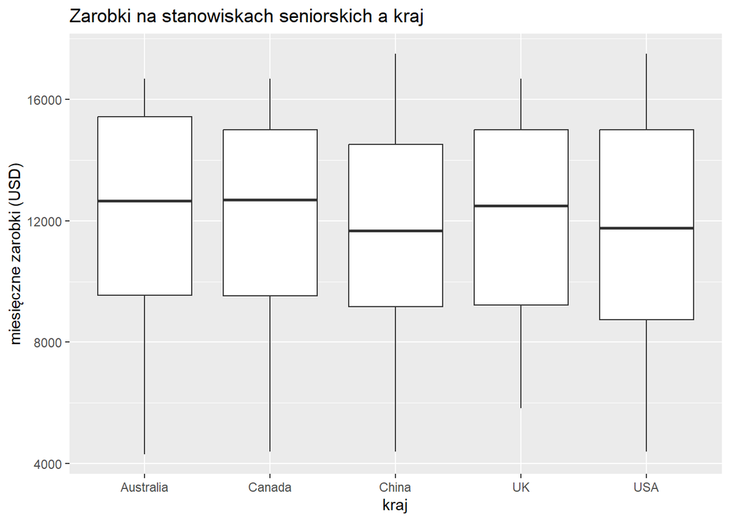

```r
senior_data <- salary %>%
  filter(Senior == "Tak")

ggplot(senior_data, aes(x = Country, y = Monthly.salary)) +
  geom_boxplot() +
  labs(title = "Zarobki na stanowiskach seniorskich a kraj",
       x = "kraj",
       y = "miesięczne zarobki (USD)")
```

```r
statystyki_opisowe <- senior_data %>%
  group_by(Country, Senior) %>%
  summarise(
    Liczba_Osób = n(),
    Średnia_Zarobków = mean(Monthly.salary),
    Mediana_Zarobków = median(Monthly.salary),
    Odchylenie_Standardowe = sd(Monthly.salary),
    Minimum_Zarobków = min(Monthly.salary),
    Maksimum_Zarobków = max(Monthly.salary)
  )

kable(statystyki_opisowe, format = "html") %>%
  kable_styling(full_width = FALSE)
```

| Country | Senior | Liczba_Osób | Średnia_Zarobków | Mediana_Zarobków | Odchylenie_Standardowe | Minimum_Zarobków | Maksimum_Zarobków |
| --- | --- | --- | --- | --- | --- | --- | --- |
| Australia | Tak | 186 | 12270.52 | 12645.12 | 3063.617 | 4319.250 | 16666.67 |
| Canada | Tak | 201 | 12166.40 | 12683.58 | 3236.108 | 4394.250 | 16666.67 |
| China | Tak | 206 | 11814.71 | 11666.67 | 3136.553 | 4402.583 | 17500.00 |
| UK | Tak | 190 | 12124.30 | 12500.00 | 3080.747 | 5833.333 | 16666.67 |
| USA | Tak | 176 | 11679.12 | 11767.96 | 3302.648 | 4402.583 | 17500.00 |

Można zauważyć, że najbardziej opłaca się zajmować stanowisko seniora w Australii, gdyż średnia zarobków osoby zajmującej stanowisko seniora w tym kaju jest największa spośród tych pięciu kraji.

Na końcu zajmę się zmienną `(Job Title)` czy od czegoś zależy?

```r
nlevels(salary$Job.Title)
```

```
## [1] 129
```

Wcześniej zamieniłam ją na typ factor. Teraz dzięki funkcji `(nlevels)` widzę, że mam w danych 129 różnych zawodów. Wybiorę kilka z nich i przeprowadzę analize.

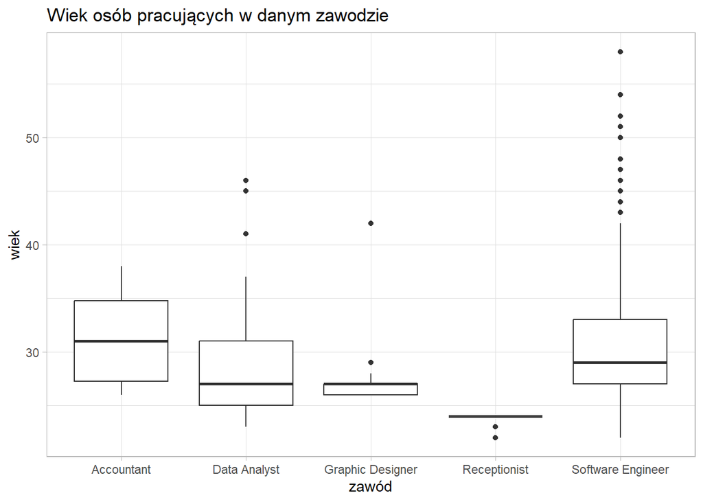

```r
salary %>%
  filter(Job.Title %in% c("Accountant", "Data Analyst", "Graphic Designer"  , "Receptionist", "Software Engineer")) %>%
  ggplot() +
  geom_boxplot(aes(x = as.factor(Job.Title), y = Age)) +
  theme_light() +
  labs(title = "Wiek osób pracujących w danym zawodzie",
       x = "zawód",
       y = "wiek")
```

Widać zróżnicowanie w wieku ze wzgędu na wykonywany zawód. W zawodach, które wymagają doświadczenia można dostrzec, że osoby obejmujące te pozycje są starsze.

A czy nasze wykształcenie wpływa na wykonywany zawód?

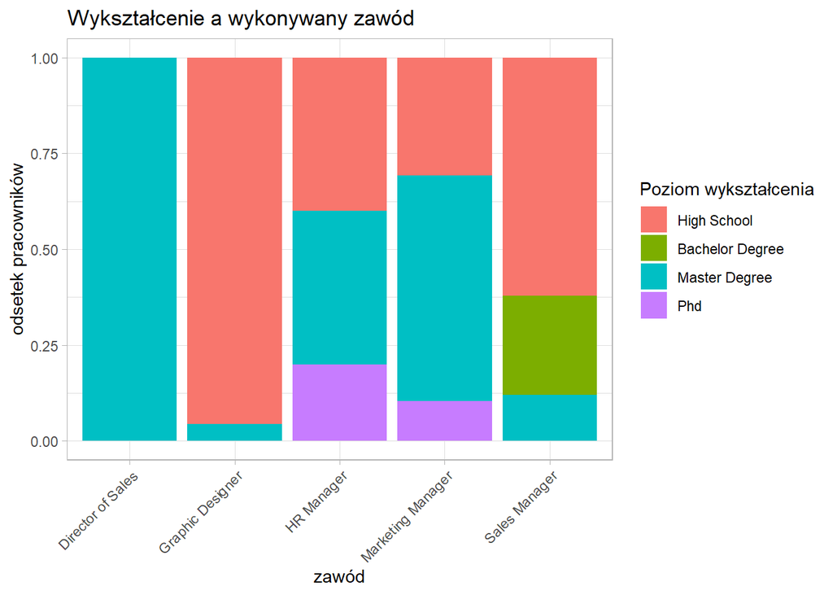

```r
salary %>%
  filter(Job.Title %in% c("Director of Sales", "Sales Manager", "Marketing Manager", "Graphic Designer", "HR Manager")) %>%
  ggplot() +
  geom_bar(aes(x = Job.Title, fill = Education.Level), position = "fill", show.legend = TRUE) +
  theme_light() +
  labs(title = "Wykształcenie a wykonywany zawód",
       x = "zawód",
       y = "odsetek pracowników",
       fill = "Poziom wykształcenia") +
  theme(axis.text.x = element_text(angle = 45, hjust = 1))
```

Widać, że duża część zawodów wymaga od pracownika wyższego wykształcenia. Im wyższe zajmowane stanowisko - tym jest oczekiwane wyższe wykształcenie.

### Podsumowanie

Analiza tego zbioru danych dostarczyła wielu zależności pomiędzy zmiennymi, a wysokością wynagrodzenia. Dzięki informacjom na temat stanowisk pracy, sektorów zawodowych, lokalizacji geograficznych, płci, wieku i lat doświadczenia, udało mi się zidentyfikować czynniki mające wpływ na poziom wynagrodzenia i te, które mają mniejszy wpływ.